# GGPLOT2

Adapted from **Hadley Wickam's book** called *ggplot2 (Springer)* The script roughly parallels text in chapter 2.

1. Introductory comments
2. A quick look at the data and taking sample
3. Some initial graphics
4. Categorical variables and symbol appearance
5. A different data set, transformation to factors
6. Specifying geoms
7. Summary geoms

**DUE:**  
One plot you choose from each of the sections 3, 4, 5, 6 (one of the smooth plots), and 7.

### **1. Introductory comments**

Leland Wilkinson, author of “The Grammar of Graphics,” created a coherent way to specify (and construct) as wide range of graphics.

When Hadley Wickam was a statistics PhD student at Iowa State he developed a layered grammar based on Lee's work. Hadley implemented this and made it available in R via the ggplot2 package. While he has not yet provided full implementation, what is available will produce a wide range of graphics with relative ease. Hadley is now working for R-Tools Technology Inc. whose product include R-Studio. I heard that one his projects is working on a faster version of ggplot2.

Historically this class made more use of the lattice package. This is a powerful and sophisticated tool for producing a wide range of graphics. ggplot2 also produce a wide range of graphics. The syntax seems to have shorter learning curve and the package is rapidly increasing in popularity.  
Hence this class will emphasize ggplot2 more than lattice.

This assignment features part of ggplot qplot because it conveys some of the clarity and power of grammar of graphics specification. While I really like the default white grid lines, gray background and horizontal grid line labels, there are several graphics below where I would change the defaults. Please to not take this assignmentas a complete endorsement of the appearance.  
Also note that qplot expects the data to be in a data.frame.

Many of my graphic designs used detailed control of R's base level graphics to address my design tasks. Over time I am revising these the plot production is easier. For example there is now a micromapST package for producing state linked micromaps. Others are also at work making it easier to produce graphics that follow some my designs.

### **2. A quick look at the diamond data and taking a sample**

Select the install item under the package menu of the R GUI windows.  
Select a mirror site, then the ggplot2 packages and install it.

```r
library(ggplot2)  #install it before calling it!
dim(diamonds)  #53940 10, a lot of rows
```

```
## [1] 53940    10
```

```r
head(diamonds)  # look at the first 6 rows
```

```
##   carat       cut color clarity depth table price    x    y    z
## 1  0.23     Ideal     E     SI2  61.5    55   326 3.95 3.98 2.43
## 2  0.21   Premium     E     SI1  59.8    61   326 3.89 3.84 2.31
## 3  0.23      Good     E     VS1  56.9    65   327 4.05 4.07 2.31
## 4  0.29   Premium     I     VS2  62.4    58   334 4.20 4.23 2.63
## 5  0.31      Good     J     SI2  63.3    58   335 4.34 4.35 2.75
## 6  0.24 Very Good     J    VVS2  62.8    57   336 3.94 3.96 2.48
```

```r
tail(diamonds)  # look at the last 6 rows
```

```
##       carat       cut color clarity depth table price    x    y    z
## 53935  0.72   Premium     D     SI1  62.7    59  2757 5.69 5.73 3.58
## 53936  0.72     Ideal     D     SI1  60.8    57  2757 5.75 5.76 3.50
## 53937  0.72      Good     D     SI1  63.1    55  2757 5.69 5.75 3.61
## 53938  0.70 Very Good     D     SI1  62.8    60  2757 5.66 5.68 3.56
## 53939  0.86   Premium     H     SI2  61.0    58  2757 6.15 6.12 3.74
## 53940  0.75     Ideal     D     SI2  62.2    55  2757 5.83 5.87 3.64
```

New data sets sometimes have problems that are immediately spotted:

```r
summary(diamonds)
```

```
##      carat              cut        color        clarity
##  Min.   :0.200   Fair     : 1610   D: 6775   SI1    :13065
##  1st Qu.:0.400   Good     : 4906   E: 9797   VS2    :12258
##  Median :0.700   Very Good:12082   F: 9542   SI2    : 9194
##  Mean   :0.798   Premium  :13791   G:11292   VS1    : 8171
##  3rd Qu.:1.040   Ideal    :21551   H: 8304   VVS2   : 5066
##  Max.   :5.010                     I: 5422   VVS1   : 3655
##                                    J: 2808   (Other): 2531
##      depth          table          price             x
##  Min.   :43.0   Min.   :43.0   Min.   :  326   Min.   : 0.00
##  1st Qu.:61.0   1st Qu.:56.0   1st Qu.:  950   1st Qu.: 4.71
##  Median :61.8   Median :57.0   Median : 2401   Median : 5.70
##  Mean   :61.8   Mean   :57.5   Mean   : 3933   Mean   : 5.73
##  3rd Qu.:62.5   3rd Qu.:59.0   3rd Qu.: 5324   3rd Qu.: 6.54
##  Max.   :79.0   Max.   :95.0   Max.   :18823   Max.   :10.74
##
##        y               z
##  Min.   : 0.00   Min.   : 0.00
##  1st Qu.: 4.72   1st Qu.: 2.91
##  Median : 5.71   Median : 3.53
##  Mean   : 5.73   Mean   : 3.54
##  3rd Qu.: 6.54   3rd Qu.: 4.04
##  Max.   :58.90   Max.   :31.80
##
```

Get a random sample after setting the random sample seed. This make sure we can get the same random sample again if we need it.

```r
set.seed(1137)  # This sets the random number seed
rowSubscripts = sample(nrow(diamonds), 100)  # sample size 100
rowSubscripts
```

```
##   [1] 17805  2216 30176  9670 12193 25175 36726 12091  7632  4016 46039
##  [12] 48772  4144 52162 46808 17190 27832 51909 51081  3949  6083 44450
##  [23] 22311  4347 45597 44099 25580  7112  3241 28695  7179   240 36354
##  [34] 21956 19419  4500 48904  5786 40223 52192 20189 44008 12396 12374
##  [45] 47435 50768 28709 46076 31717 38519 49223 31794 45092 21395 29743
##  [56]  9960 32036 37348 23052 33128 10225 49677  4330 33430 19504  2802
##  [67] 40237 21859 15297  1765 17750 37126 53393 41382 26898 34610 21164
##  [78] 43038 11991 17303 31782 24939 17609  9176 37183 23292 51810 43594
##  [89] 49846 19699 10952 31101  4311 11024 14818  5549  2005 17507 19574
## [100] 53365
```

```r
diamondSamp = diamonds[rowSubscripts, ]  # extract the rows take all the columns
diamondSamp
```

```
##       carat       cut color clarity depth table price    x    y    z
## 17805  1.50      Good     J     VS2  63.6  58.0  7177 7.20 7.23 4.59
## 2216   0.80 Very Good     H     VS1  62.7  56.0  3144 5.88 5.96 3.71
## 30176  0.38     Ideal     H     VS1  61.1  55.0   721 4.68 4.72 2.87
## 9670   1.02     Ideal     E     SI2  62.0  59.0  4645 6.43 6.40 3.98
## 12193  1.06     Ideal     H     SI1  61.7  56.0  5188 6.58 6.55 4.05
## 25175  1.51 Very Good     E     VS2  63.2  56.0 13757 7.28 7.22 4.58
## 36726  0.32     Ideal     E    VVS1  60.9  57.0   954 4.42 4.45 2.70
## 12091  1.06 Very Good     G     SI1  63.4  58.0  5163 6.44 6.47 4.09
## 7632   1.00      Fair     E     SI2  65.9  62.0  4265 6.09 6.02 3.99
## 4016   1.00     Ideal     E      I1  61.8  56.0  3520 6.38 6.43 3.96
## 46039  0.57     Ideal     E     SI1  61.8  57.0  1728 5.33 5.28 3.28
## 48772  0.57   Premium     D     VS2  60.8  59.0  2019 5.38 5.34 3.26
## 4144   0.90     Ideal     I     VS1  62.4  57.0  3545 6.17 6.21 3.86
## 52162  0.60     Ideal     D     VS2  61.4  53.0  2473 5.45 5.50 3.36
```

[output cut: 86 more lines]

### **3. Some initial graphics**

Note that ggplot2 features two graphics functions qplot() and ggplot(). The first starts with a “q” (lower case Q).

```r
colnames(diamondSamp)
```

```
##  [1] "carat"   "cut"     "color"   "clarity" "depth"   "table"   "price"
##  [8] "x"       "y"       "z"
```

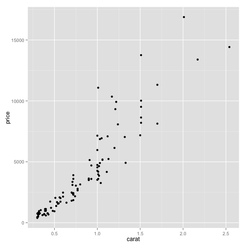

```r
qplot(carat, price, data = diamondSamp)  # data = tells R the data.frame to use R can then access the columns by their names. The first argument to qplot goes on the x axis
```

The plotted x and y variables can be calculated from data.frame variables

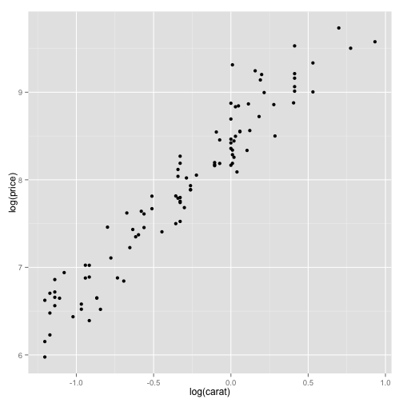

```r
qplot(log(carat), log(price), data = diamondSamp)
```

x*y*z is a new variable related to the volume(see picture page 10)

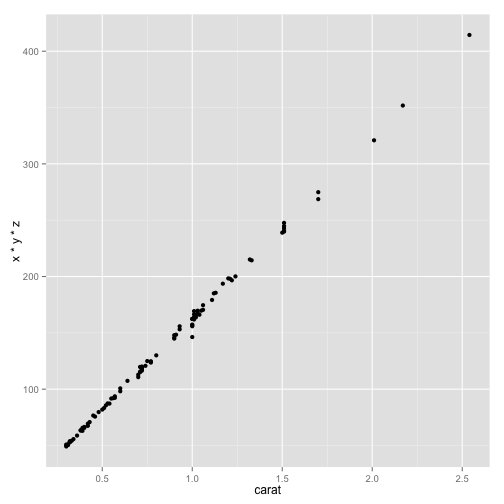

```r
qplot(carat, x * y * z, data = diamondSamp)
```

The plot below plots the full data set and takes a while:

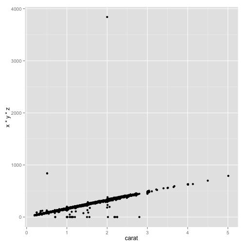

```r
qplot(carat, x * y * z, data = diamonds)
```

There are outliers that limit resolution for the body of the data. Sampling can miss outliers.

### 4. Categorical variables and geom appearance

A geom is a geometric object such as point, line, polygon, confidence bounds for a regression line and so on.  
The default geom is a point.

*Lee Wilkinson* used the word aesthetics to characterize non-positional aspects of object appearance. For points, the aesthetics are primarily color, size and shape. The qplot() argument key words are colour(or color), size and shape. (Colour is British spelling for the key word.) These are followed respectively by categorical variables encoded as factors. Constants can be provided as argument values using the I() function. The color transparency can be controlled use the alpha keyword.

Note the automatic generation of legends. This really helps in producing decent graphics.

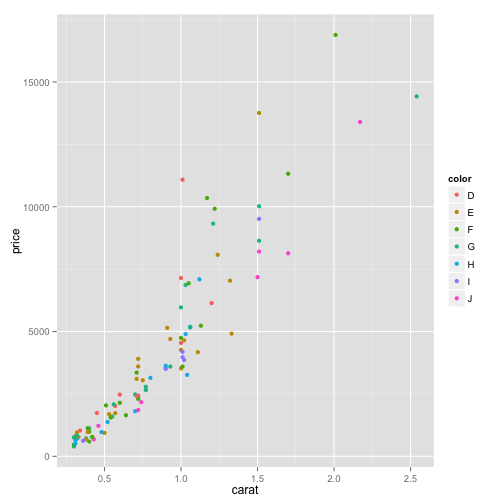

```r
qplot(carat, price, colour = color, data = diamondSamp)
```

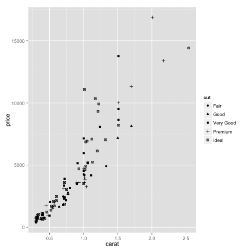

```r
qplot(carat, price, shape = cut, data = diamondSamp)
```

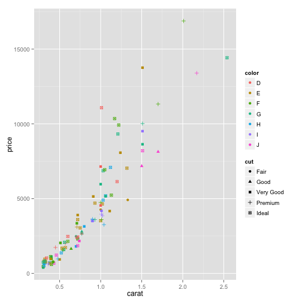

```r
qplot(carat, price, color = color, shape = cut, data = diamondSamp)
```

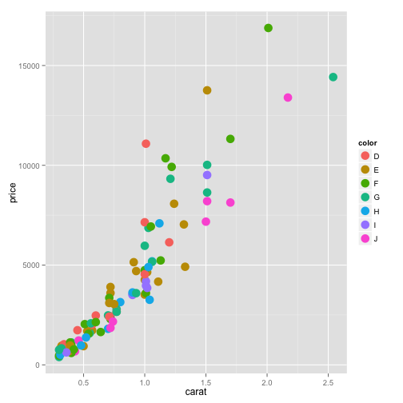

```r
qplot(carat, price, color = color, size = I(5), data = diamondSamp)
```

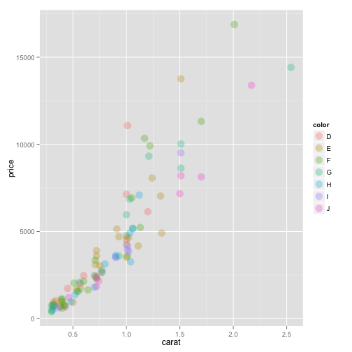

```r
qplot(carat, price, color = color, size = I(5), alpha = I(3/10), data = diamondSamp)
```

### 5. A different data set and transformation to factors

```r
dim(mpg)
```

```
## [1] 234  11
```

```r
head(mpg)
```

```
##   manufacturer model displ year cyl      trans drv cty hwy fl   class
## 1         audi    a4   1.8 1999   4   auto(l5)   f  18  29  p compact
## 2         audi    a4   1.8 1999   4 manual(m5)   f  21  29  p compact
## 3         audi    a4   2.0 2008   4 manual(m6)   f  20  31  p compact
## 4         audi    a4   2.0 2008   4   auto(av)   f  21  30  p compact
## 5         audi    a4   2.8 1999   6   auto(l5)   f  16  26  p compact
## 6         audi    a4   2.8 1999   6 manual(m5)   f  18  26  p compact
```

```r
tail(mpg)
```

```
##     manufacturer  model displ year cyl      trans drv cty hwy fl   class
## 229   volkswagen passat   1.8 1999   4   auto(l5)   f  18  29  p midsize
## 230   volkswagen passat   2.0 2008   4   auto(s6)   f  19  28  p midsize
## 231   volkswagen passat   2.0 2008   4 manual(m6)   f  21  29  p midsize
## 232   volkswagen passat   2.8 1999   6   auto(l5)   f  16  26  p midsize
## 233   volkswagen passat   2.8 1999   6 manual(m5)   f  18  26  p midsize
## 234   volkswagen passat   3.6 2008   6   auto(s6)   f  17  26  p midsize
```

```r
summary(mpg)
```

```
##      manufacturer                 model         displ           year
##  dodge     :37    caravan 2wd        : 11   Min.   :1.60   Min.   :1999
##  toyota    :34    ram 1500 pickup 4wd: 10   1st Qu.:2.40   1st Qu.:1999
##  volkswagen:27    civic              :  9   Median :3.30   Median :2004
##  ford      :25    dakota pickup 4wd  :  9   Mean   :3.47   Mean   :2004
##  chevrolet :19    jetta              :  9   3rd Qu.:4.60   3rd Qu.:2008
##  audi      :18    mustang            :  9   Max.   :7.00   Max.   :2008
##  (Other)   :74    (Other)            :177
##       cyl              trans    drv          cty            hwy
##  Min.   :4.00   auto(l4)  :83   4:103   Min.   : 9.0   Min.   :12.0
##  1st Qu.:4.00   manual(m5):58   f:106   1st Qu.:14.0   1st Qu.:18.0
##  Median :6.00   auto(l5)  :39   r: 25   Median :17.0   Median :24.0
##  Mean   :5.89   manual(m6):19           Mean   :16.9   Mean   :23.4
##  3rd Qu.:8.00   auto(s6)  :16           3rd Qu.:19.0   3rd Qu.:27.0
##  Max.   :8.00   auto(l6)  : 6           Max.   :35.0   Max.   :44.0
##                 (Other)   :13
##  fl             class
##  c:  1   2seater   : 5
##  d:  5   compact   :47
##  e:  8   midsize   :41
##  p: 52   minivan   :11
##  r:168   pickup    :33
##          subcompact:35
##          suv       :62
```

If you look closely at the summary you can see the manufacturer is already a categorical variable with levels such as dodge, toyota, …

You can see that cyl (for cylinder)is numeric but discrete integers. This is easily converted into a factor.

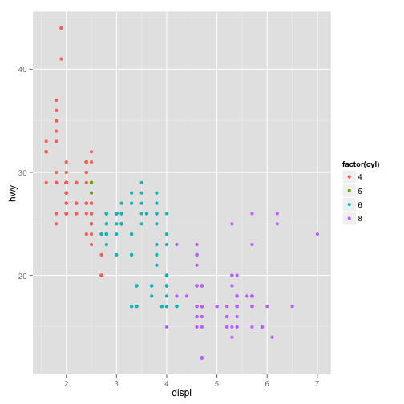

```r
qplot(displ, hwy, data = mpg, color = factor(cyl))
```

### 6. Specifying geoms

Geoms are different kinds of geometric objects to render.

- geom = “point” plots points and is the default geom
- geom = “line” and “path” plot lines and paths. The line travels from left to right. A path can move in all directions and cross over itself

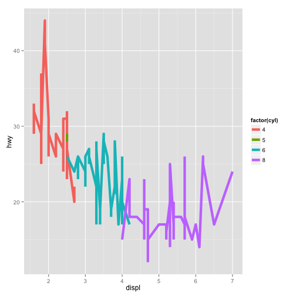

```r
qplot(displ, hwy, data = mpg, colour = factor(cyl), geom = c("line"), size = I(2))
```

- geom = “smooth” produces a smooth approximation to a functional relationship and its standard error.

```
## geom_smooth: method="auto" and size of largest group is <1000, so using loess. Use 'method = x' to change the smoothing method.
```

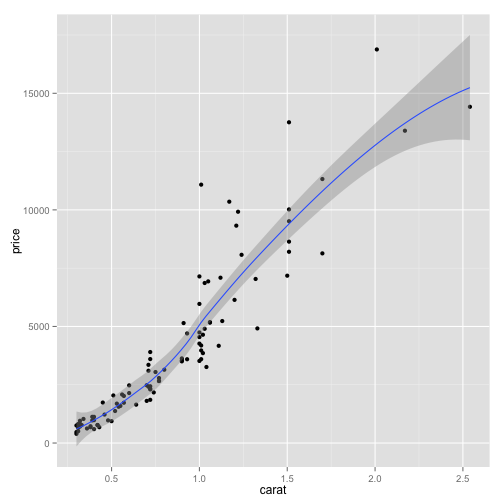

```r
qplot(carat, price, data = diamondSamp, geom = c("point", "smooth"))
```

```
## geom_smooth: method="auto" and size of largest group is <1000, so using loess. Use 'method = x' to change the smoothing method.
```

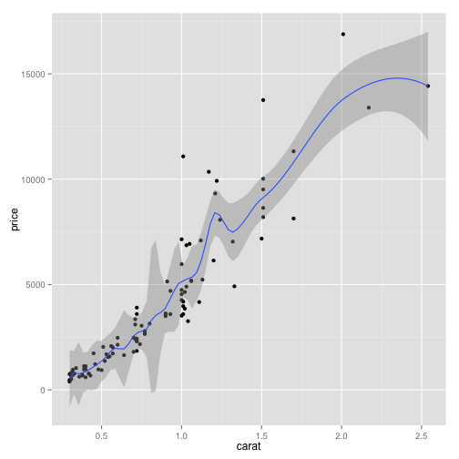

```r
qplot(carat, price, data = diamondSamp, geom = c("point", "smooth"), span = 0.2)
```

```
## geom_smooth: method="auto" and size of largest group is <1000, so using loess. Use 'method = x' to change the smoothing method.
```

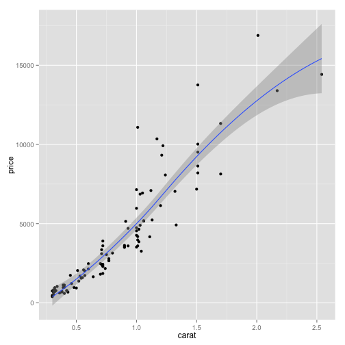

```r
qplot(carat, price, data = diamondSamp, geom = c("point", "smooth"), span = 1)
```

For modest (n <= 1000) sample sizes ggplot uses loess to smooth. More will be said later about additional packages and smoothes for larger data sets.

### 7. More on Geoms

A list appears on *page 56*. Below are some more examples.

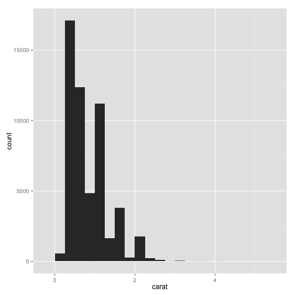

```r
qplot(carat, data = diamonds, geom = "histogram", binwidth = 0.25)
```

```
## stat_bin: binwidth defaulted to range/30. Use 'binwidth = x' to adjust this.
```

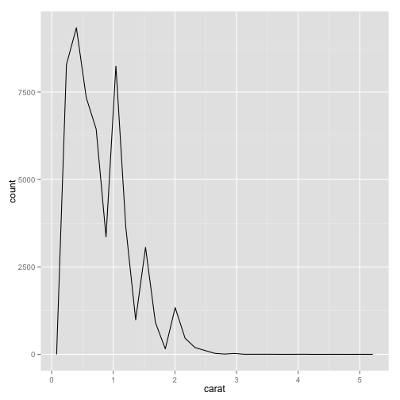

```r
qplot(carat, data = diamonds, geom = "freqpoly")
```

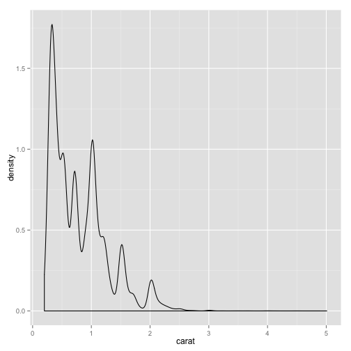

```r
qplot(carat, data = diamonds, geom = "density")
```

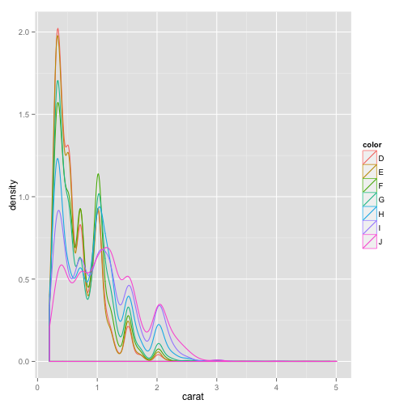

```r
qplot(carat, data = diamonds, geom = "density", colour = color)
```

- geom= 'bar" is for a categorical variable

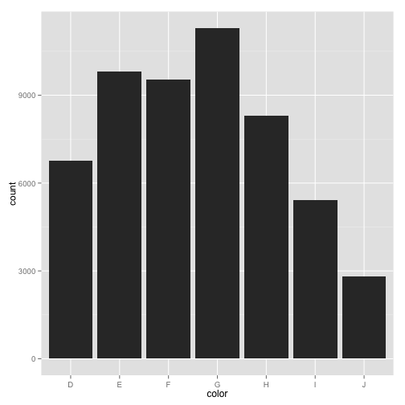

```r
qplot(color, data = diamonds, geom = "bar")
```